# Demonstrate the Urban Institute quarto Theme

This is an example subtitle

Authors

Aaron R. Williams and Erika Tyagi

Published

August 15, 2022

## 1 Introduction

This analysis was originally by Mine Çetinkaya-Rundel and comes from the Quarto documentation. In this analysis, we build a model predicting sale prices of houses based on data on houses that were sold in the Duke Forest neighborhood of Durham, NC around November 2020. Let’s start by loading the packages we’ll use for the analysis.

```r
library(openintro)  # for data
library(tidyverse)  # for data wrangling and visualization
library(knitr)      # for tables
library(broom)      # for model summary
library(urbnthemes) # for ggplot2 theme

set_urbn_defaults(style = "print")
```

We present the results of exploratory data analysis in Section 2 and the regression model in Section 4.

We’re going to do this analysis using literate programming (Knuth 1984).

## 2 Data Visualization

The data contains 98 houses. As part of the exploratory analysis let’s visualize and summarize the relationship between areas and prices of these houses.

Figure 1 shows two histograms displaying the distributions of `price` and `area` individually.

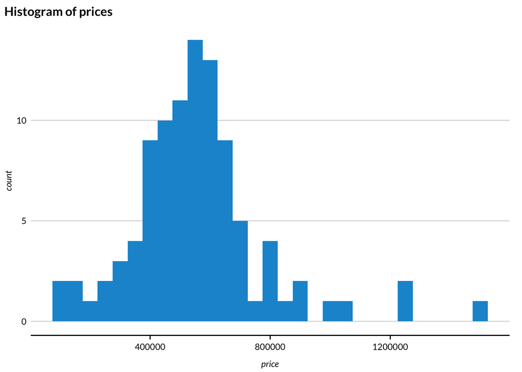

(a) Histogram of `price`s

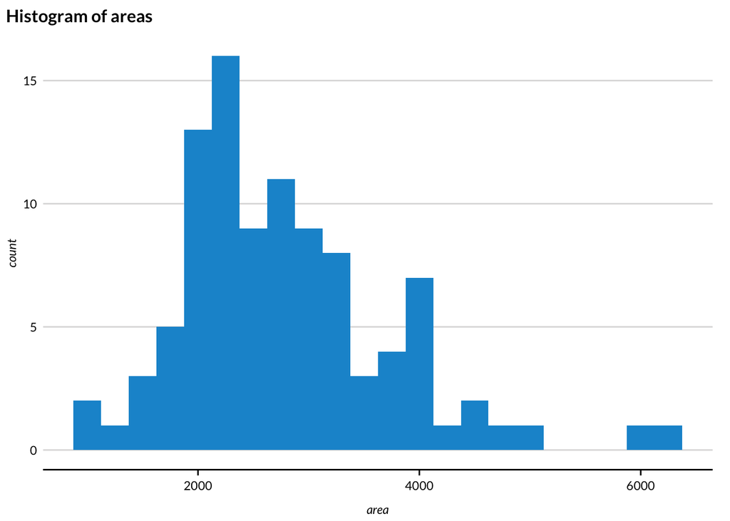

(b) Histogram of `area`s

Figure 1: Histograms of individual variables

```r
ggplot(duke_forest, aes(x = price)) +
  geom_histogram(binwidth = 50000) +
  labs(title = "Histogram of prices")

ggplot(duke_forest, aes(x = area)) +
  geom_histogram(binwidth = 250) +
  labs(title = "Histogram of areas")
```

Figure 2 displays the relationship between these two variables in a scatterplot.

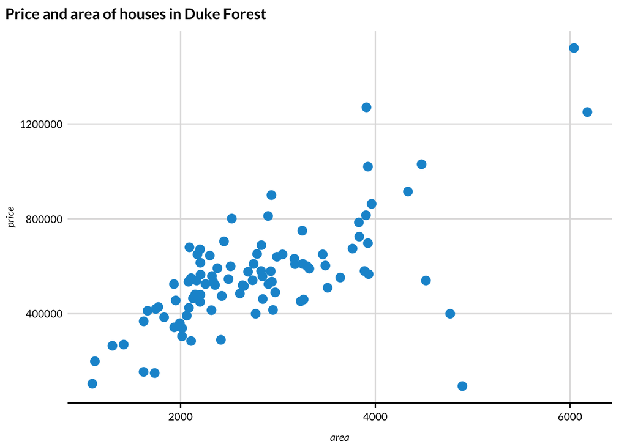

Figure 2: Scatterplot of price vs. area of houses in Duke Forest

```r
duke_forest %>%
  ggplot(aes(x = area, y = price)) +
  geom_point() +
  labs(title = "Price and area of houses in Duke Forest") +
  scatter_grid()
```

## 3 Data Tables

The default for df-print is kable. This is the only type of table that works with the table references. kable works well until there is tons of data, where paged thrives.

Table 1 displays basic summary statistics for these two variables.

```r
duke_forest %>%
  summarise(
    `Median price` = median(price),
    `IQR price` = IQR(price),
    `Median area` = median(area),
    `IQR area` = IQR(area),
    `Correlation, r` = cor(price, area)
  ) %>%
  kable(digits = c(0, 0, 0, 0, 2))
```

Table 1: Summary statistics for price and area of houses in Duke Forest (kable)

| Median price | IQR price | Median area | IQR area | Correlation, r |
| --- | --- | --- | --- | --- |
| 540000 | 193125 | 2623 | 1121 | 0.67 |

## 4 Modeling

### 4.1 First Model

We can fit a simple linear regression model of the form shown in Equation 1.

$$price = \hat{\beta}_0 + \hat{\beta}_1 \times area + \epsilon
\tag{1}$$

Table 2 shows the regression output for this model.

```r
price_fit <- lm(price ~ area, data = duke_forest)

price_fit %>%
  tidy() %>%
  kable(digits = c(0, 0, 2, 2, 2))
```

Table 2: Linear regression model for predicting price from area

| term | estimate | std.error | statistic | p.value |
| --- | --- | --- | --- | --- |
| (Intercept) | 116652 | 53302.46 | 2.19 | 0.03 |
| area | 159 | 18.17 | 8.78 | 0.00 |

### 4.2 Second Model

Let’s fit a more complicated multiple linear regression model of the form shown in Equation 2.

$$price = \hat{\beta}_0 + \hat{\beta}_1 \times area + \hat{\beta}_2 \times bedrooms + \epsilon
\tag{2}$$

Table 3 shows the regression output for this model.

```r
price_fit2 <- lm(price ~ area + bed, data = duke_forest)

price_fit2 %>%
  tidy() %>%
  kable(digits = c(0, 0, 2, 2, 2))
```

Table 3: Second linear regression model for predicting price from area

| term | estimate | std.error | statistic | p.value |
| --- | --- | --- | --- | --- |
| (Intercept) | 81709 | 87586.47 | 0.93 | 0.35 |
| area | 153 | 22.16 | 6.91 | 0.00 |
| bed | 14037 | 27853.62 | 0.50 | 0.62 |

## 5 Callouts

**Note**

This template is incomplete and we are always looking for help to expand it!

**Warning**

Caution, quarto is so powerful you may abandon LaTeX.

**Important**

Reproducible work is a cornerstone of quality research. Quarto makes reproducible work easy and fun.

**Tip**

Use `library(urbntemplates)` to access Urban Institute quarto templates.

**Danger**

Quarto may transform the way the Urban Institute communicates research.

## References

Knuth, D. E. 1984. “Literate Programming.” *The Computer Journal* 27 (2): 97–111. https://doi.org/10.1093/comjnl/27.2.97.